# Modeling and prediction for movies

Wesley Galvão

April 2019

## Setup

### Load packages

```r
library(ggplot2)    # library to create plots
library(dplyr)      # data manipulation
library(statsr)     # statistics functions
library(grid)       # arrange plots
library(gridExtra)  # arrange plots
library(GGally)     # library to create plots
library(ggpubr)     # Functions for creating and customizing 'ggplot2'
library(gtable)     # Tools to make it easier to work with "tables" of 'grobs'
library(corrplot)   # Plot correlation matrix
library(leaps)      # Regression subset selection
library(MASS)       # Functions and datasets to support Venables and Ripley
```

### Load data

```r
load("movies.Rdata")
```

## Part 1: Data

#### The data

The dataset called **movies** is comprised of 651 randomly sampled movies produced and released from 1970 to 2014. It was derived from an observational study and contains information about movies from Rotten Tomatos and IMDB source. Each observation (movie) is composed of variables that describe some characteristics of the same. The Coodbook of variables can be found here.

#### Generalizability and causality

As the present data was derived from an observational study, so the sample is indeed generalizable to the entire population.

However, the data cannot be used to establish a causal relation between the variables of interest, that this, the data can be used only to correlate movie parameters to audience score, but cannot be used toinfer causality because there was no random assignment to the explanatory and independent variables.

#### Potential Bias

The data about critics rating, IMDB rating, IMDB number of votes are only collected from either IMDB or Rotten Tomatoes which is limited to only people who are register to the platforms.

#### Importante Note

For a better reading experience, most of the codes are found in Appendix. In the course of the narrative the omitted codes will be referenced by the corresponding number. You can access it here

## Part 2: Research question

*What are the attributes that make a movie popular?*

To answer this question, it will be necessary to use the multiple linear regression method in conjunction with a model selection strategy called **Backward Elimination** in order to obtain the **parsimonious model**.

## Part 3: Exploratory data analysis

### Knowing the dataset

To start the exploration, a new dataframe containing all variables was created. All the *NA’s* were dropped so that only valid observations could be analyzed.

```r
# remove NA's and copy to a new new dataset and
movies_data <- na.omit(movies)
```

As a way to examine the dimmension of the dataset, let’s see the data summary where show the number of observations and variables. 1

[output not shown]

In order to know more about the interested response variable `audience_score`, it’s possible to get the summary from this as well. 2

```
## # A tibble: 1 x 7
##     Min `1st Qu` Median  Mean `3rd Qu`   Max    SD
##   <dbl>    <dbl>  <dbl> <dbl>    <dbl> <dbl> <dbl>
## 1    11       46     65  62.2       80    97  20.2
```

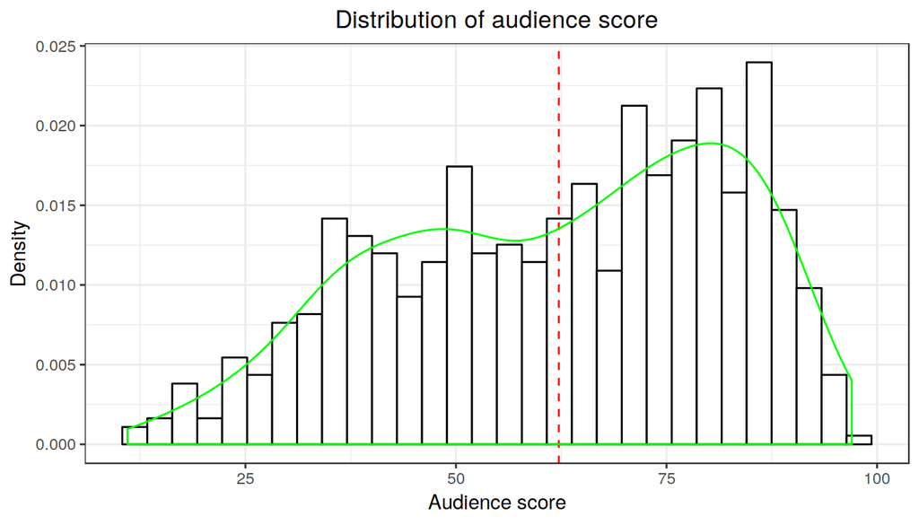

### Exploring categorical variables

Now it is interesting to explore some relevants categorical variables and what is the proportion of observations for each level 4. The chosen variables are `genre`, `title_type`, `critics_rating`, `audience_rating` , `mpaa_rating` and `mpaa_rating`.

Here are the charts that shows the percentage of observations of each levels to the referred variable 5

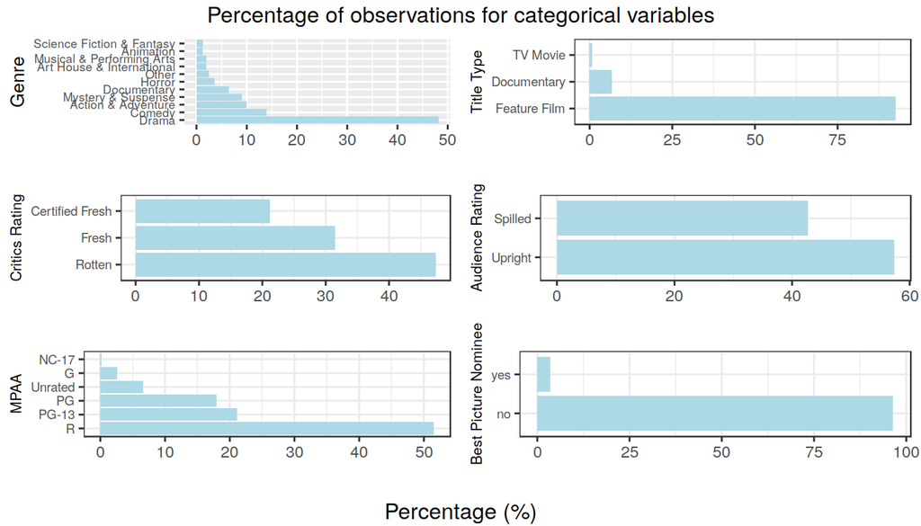

Once aware of how the levels of categorical variables are distributed in the data set, it is worth analyzing how these variables are correlated with the response variable of interest. To do this, let’s take a look at the density and boxplot graphs

Note that the colors corresponding to the category levels of the boxplot on the right side are the same for the density plot. 6.

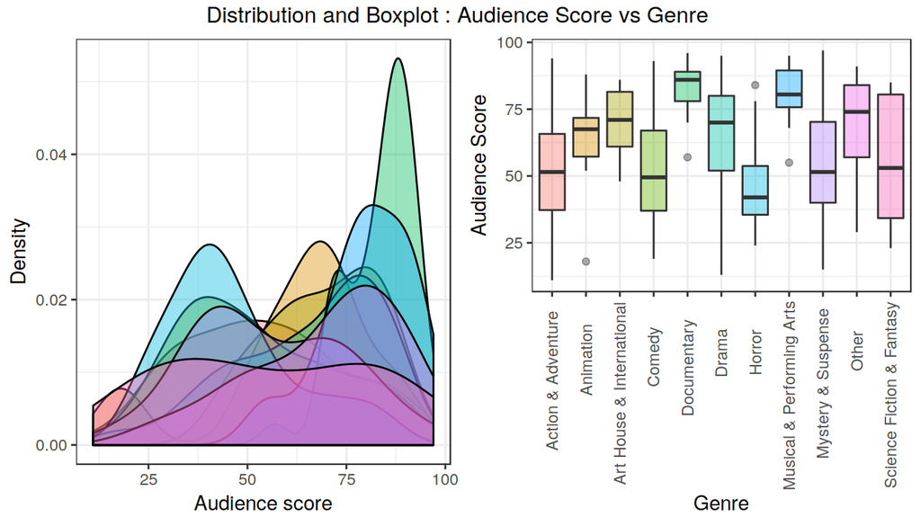

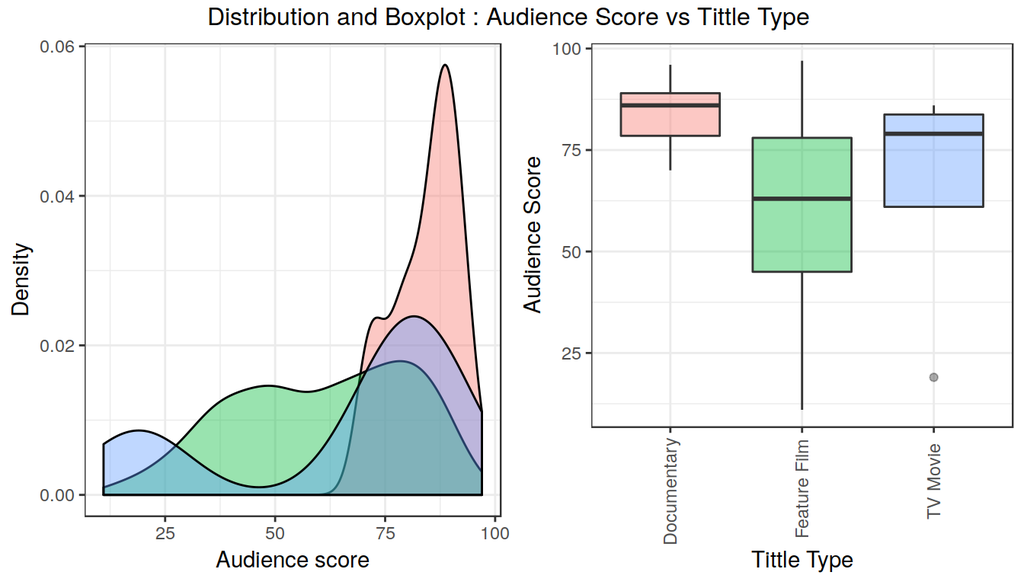

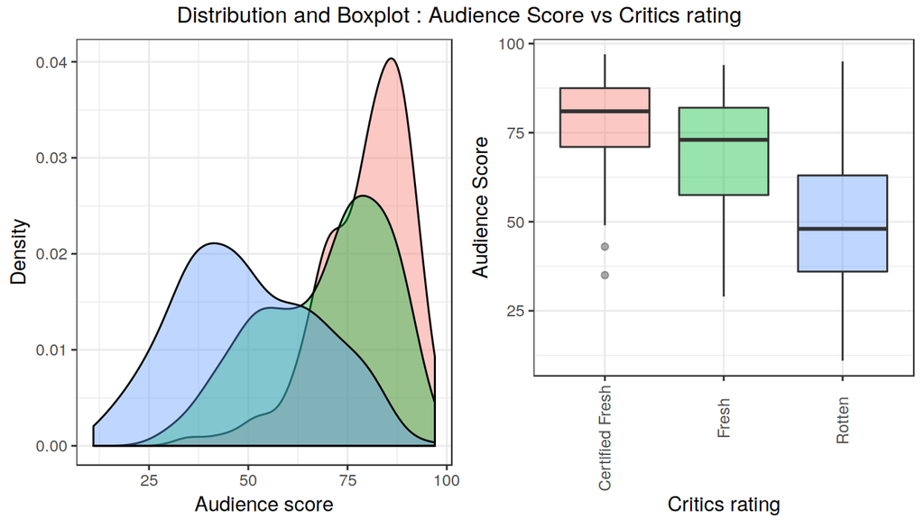

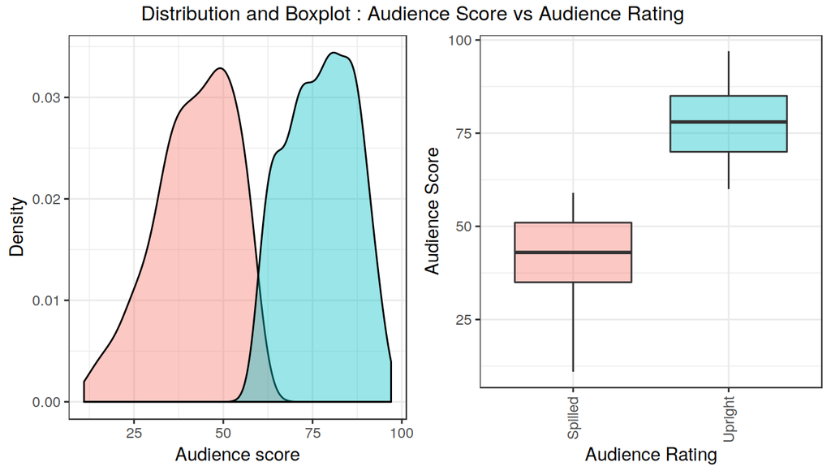

### Exploring numerical variables

Similarly, it is possible to verify the correlation between numerical explanatory variables and the variable `audience_score`. To do so, we do the analysis through the scatter plots. 7

Note that the observations were colored according to the level of the `critics_rating` variable.

Some of the graphs present a reasonable correlation with the response variable, while others apparently do not have a clear correlation.

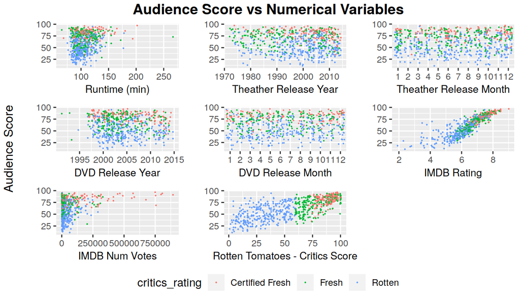

To conclude this section, some of the numerical variables that visually presented some kind of correlation with the response variable were selected and then the summaries of each one were made. 8

- Runtime summary

```
##    Min. 1st Qu.  Median    Mean 3rd Qu.    Max.
##    65.0    93.0   103.0   106.5   116.0   267.0
```

- IMDB Rating summary

```
##    Min. 1st Qu.  Median    Mean 3rd Qu.    Max.
##   1.900   5.900   6.600   6.486   7.300   9.000
```

- IMDB Num Votes summary

[output not shown]

- Critics Score summary

```
##    Min. 1st Qu.  Median    Mean 3rd Qu.    Max.
##    1.00   33.00   61.00   57.43   82.50  100.00
```

## Part 4: Modeling

### Approach

Choosing the best model can sometimes be a tedious job, especially if there are many variables to consider. Sometimes including variables that do not provide good statistical evidence that can contribute to prediction can compromise the accuracy of the model.

The model that includes all the explanatory variables available in the dataset is called **full model**, but not always the full model is the best for a good predicting, so an approach is needed to select the best model.

In this project the **Backwards elimination** was the chosen approach for the selection of the best model, that is, for the selection of the **parsimonious model**.

**Backwards elimination** starts with model that includes all variables that are potential predictors. The variables are then deleted one by one from the model, excluding the variable that does not contribute to the **ajusted R²** increasement until the adjusted R² can no longer be improved.

The **ajusted R²** is a useful tool that describes the strength of a model and can be used to evaluate which predictors are adding value to the model, which means that they are improving accuracy in predicting future results.

### Model Selection

Before starting a selection of the **parsimonious model**, it is first necessary to define which is the **full model**. So, for such a definition, some variables that have only informational purpose were omitted, as they are not meaningful and can make the model very large.

Therefore, the **full model** is composed by the interested response variable `audience_score` the following explanatory variables: `title_type`, `genre`, `runtime`,`mpaa_rating`, `thtr_rel_year`, `dvd_rel_year`, `imdb_rating`, `imdb_num_votes`, `critics_rating`, `critics_score`, `audience_rating`, `best_pic_nom` and `best_pic_win`. Check codebook here

So let’s see the summary of our potential parsimonious model after backward selection had been applied. We can name this model as `backward_model1` 9

```
##
## Call:
## lm(formula = audience_score ~ genre + runtime + dvd_rel_year +
##     imdb_rating + imdb_num_votes + critics_score + audience_rating +
##     best_pic_nom, data = movies_data)
##
## Residuals:
##      Min       1Q   Median       3Q      Max
## -21.7651  -4.4943   0.4531   4.1656  23.6266
##
## Coefficients:
##                                  Estimate Std. Error t value Pr(>|t|)
## (Intercept)                     2.801e+02  1.259e+02   2.224   0.0265 *
## genreAnimation                  5.170e+00  2.597e+00   1.991   0.0469 *
## genreArt House & International -1.340e+00  2.210e+00  -0.606   0.5445
## genreComedy                     1.312e+00  1.147e+00   1.143   0.2534
## genreDocumentary                2.100e+00  1.578e+00   1.331   0.1837
## genreDrama                     -4.727e-01  9.980e-01  -0.474   0.6359
## genreHorror                    -1.722e+00  1.712e+00  -1.006   0.3150
## genreMusical & Performing Arts  3.674e+00  2.231e+00   1.647   0.1001
## genreMystery & Suspense        -3.088e+00  1.277e+00  -2.418   0.0159 *
## genreOther                      3.954e-01  1.990e+00   0.199   0.8426
## genreScience Fiction & Fantasy  1.018e-01  2.571e+00   0.040   0.9684
## runtime                        -4.349e-02  1.657e-02  -2.625   0.0089 **
## dvd_rel_year                   -1.427e-01  6.265e-02  -2.277   0.0231 *
## imdb_rating                     9.194e+00  4.876e-01  18.858   <2e-16 ***
## imdb_num_votes                  4.264e-06  2.953e-06   1.444   0.1494
## critics_score                   2.353e-02  1.537e-02   1.531   0.1262
## audience_ratingUpright          2.006e+01  7.964e-01  25.193   <2e-16 ***
## best_pic_nomyes                 3.077e+00  1.615e+00   1.905   0.0572 .
## ---
## Signif. codes:  0 '***' 0.001 '**' 0.01 '*' 0.05 '.' 0.1 ' ' 1
##
## Residual standard error: 6.824 on 601 degrees of freedom
## Multiple R-squared:  0.8888, Adjusted R-squared:  0.8856
## F-statistic: 282.5 on 17 and 601 DF,  p-value: < 2.2e-16
```

The summary indicates that the adjusted R² value is 0.8856 and the p-value < 2.2e-16.

Although we have already obtained a candidate model to be the parsimonious model, it is necessary to verify if there is evidence of colinearity between the explanatory variables.

If collinearity is verified then it will be necessary to remove one of the variables, construct a new candidate for parsimonious model and compare with the first model to check whether the exclusion of the explanatory variable has any significant relevance to the adjusted R².

To do this, let’s build a correlation matrix to verify the degree of correlation between the numeric variables, including the response variable. In this way, it will be possible to verify the degree of correlation between the response variable and the explanatory variables, and also to verify if there is collinearity between explanatory variables. 10

#### Checking collinearity

```
##                audience_score    runtime dvd_rel_year imdb_rating
## audience_score      1.0000000  0.2031201 -0.067641796  0.86054247
## runtime             0.2031201  1.0000000 -0.079098203  0.29743877
## dvd_rel_year       -0.0676418 -0.0790982  1.000000000 -0.02496433
## imdb_rating         0.8605425  0.2974388 -0.024964329  1.00000000
## imdb_num_votes      0.3035904  0.3430813  0.101535834  0.34764312
## critics_score       0.7015256  0.2000696  0.005247028  0.76199897
##                imdb_num_votes critics_score
## audience_score      0.3035904   0.701525579
## runtime             0.3430813   0.200069649
## dvd_rel_year        0.1015358   0.005247028
## imdb_rating         0.3476431   0.761998967
## imdb_num_votes      1.0000000   0.221720774
## critics_score       0.2217208   1.000000000
```

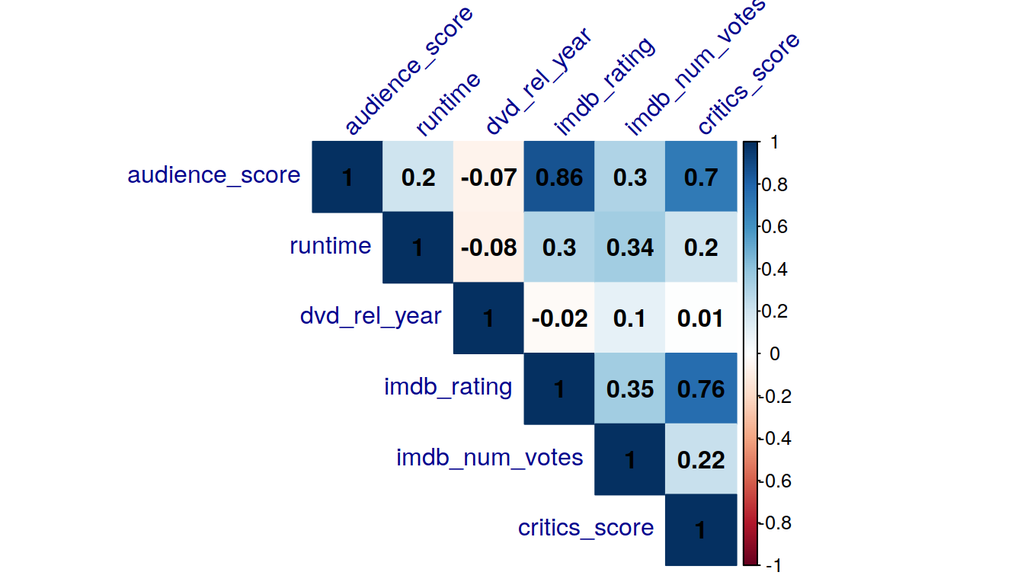

Note that the `audience_score` response variable has a strong correlation with the`imdb_rating` and `critics_score` variables, which shows a linearity correlation. But this information will be remembered later.

See now that among the explanatory variables, there is an indication of collinearity between the variables `imdb_rating` and`critics_score` with a value of 0.76

#### Comparing models

Now we will build two more models, where the second model called `backward_model2` will be built without the presence of`critics_score` variable. Similarly, a third model called `backward_model3` will be constructed without the presence of the`imdb_rating` variable.

For this, we will obtain the coefficients R² and adjusted R² of both models in order to verify in which model the exclusion of the explanatory variable affected with more significance the coefficients mentioned above. 11

- **backward_model2**
  - R² = 0.888332 and ajusted R² = 0.8853641

    ```
        audience_score ~  genre + runtime + dvd_rel_year + imdb_rating + imdb_num_votes + audience_rating + best_pic_nom
    ```

- **backward_model3**
  - R² = 0.822946 and ajusted R² = 0.8182403

    ```
        audience_score ~  genre + runtime + dvd_rel_year + critics_score + imdb_num_votes + audience_rating + best_pic_nom
    ```

If we consider the `backward_model3` model and dropp`imdb_rating` then the adjusted R² coefficient falls dramatically in relation to the `backward_model1` model. To do so, consider the `backward_model2` model as a cadidate to be the parsimonious model.

Through the ANOVA function, we will compare both `backward_model1` and`backward_model2` to see if there is any statistical evidence that if we exclude the variable `critics_score` then`backward_model2` could be the parsimonious model.

```r
#Compare backward_model1 and backward_model2
anova(backward_model1, backward_model2)
```

```
## Analysis of Variance Table
##
## Model 1: audience_score ~ genre + runtime + dvd_rel_year + imdb_rating +
##     imdb_num_votes + critics_score + audience_rating + best_pic_nom
## Model 2: audience_score ~ genre + runtime + dvd_rel_year + imdb_rating +
##     imdb_num_votes + audience_rating + best_pic_nom
##   Res.Df   RSS Df Sum of Sq      F Pr(>F)
## 1    601 27987
## 2    602 28096 -1    -109.2 2.3451 0.1262
```

#### Model diagnostics

To do the diagnostics of the model, it’s necessary to consider the following four assumptions:

1. There is a linear relationship between any numerical predictor variables and the response variable.
2. The variability of the residuals is nearly constant
3. The residuals are independent
4. The residuals of the model are nearly normal

First, see the correlation matrix again to verify the degree of linearity between the explanatory variables and the response variable. 12

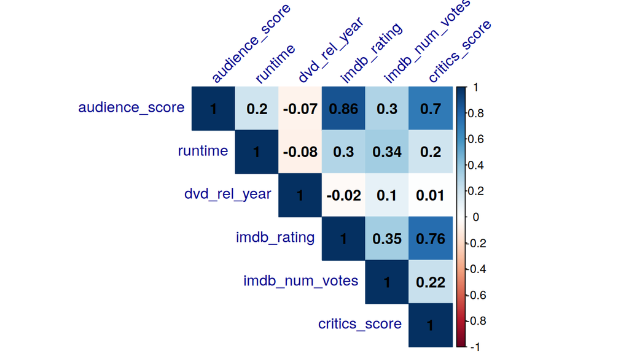

Some explanatory variables presents low degree of linearity with response variable, but we have to check the other assumptions.

The charts show that the residuals are scattered randomly around 0 for all features. Particularly, the sixth chart shows that the residuals are equally variable for low and high values. 13

[figure not shown]

Finally, the we can verify the last assumption, whether the residuals display a nearly normal distribution centred around 0 14.

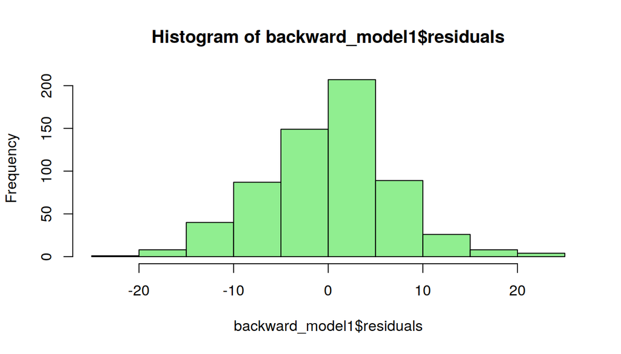

```r
# Plotting Q-Q Normal
p1 <- hist(backward_model1$residuals, col = 'lightgreen')
```

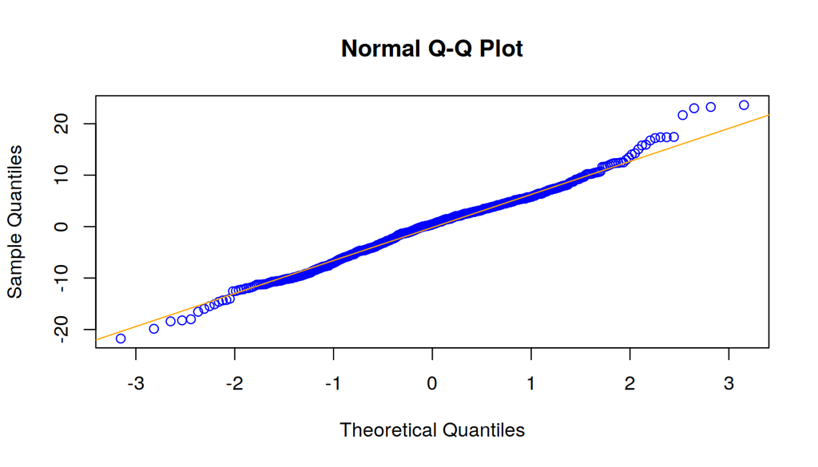

```r
p2 <- qqnorm(backward_model1$residuals, col = 'blue')
qqline(backward_model1$residuals, col = 'orange')
```

The histogram of the residuals shows a normal distribution around 0 while the Q-Q plot indicates some slight skewness, but that can not be harmful to our model.

So we can conclude that the conditions for this model are reasonable.

#### Interpretation of model coefficients

```
## Coefficients:
##                                  Estimate Std. Error t value Pr(>|t|)
## (Intercept)                     2.801e+02  1.259e+02   2.224   0.0265 *
## genreAnimation                  5.170e+00  2.597e+00   1.991   0.0469 *
## genreArt House & International -1.340e+00  2.210e+00  -0.606   0.5445
## genreComedy                     1.312e+00  1.147e+00   1.143   0.2534
## genreDocumentary                2.100e+00  1.578e+00   1.331   0.1837
## genreDrama                     -4.727e-01  9.980e-01  -0.474   0.6359
## genreHorror                    -1.722e+00  1.712e+00  -1.006   0.3150
## genreMusical & Performing Arts  3.674e+00  2.231e+00   1.647   0.1001
## genreMystery & Suspense        -3.088e+00  1.277e+00  -2.418   0.0159 *
## genreOther                      3.954e-01  1.990e+00   0.199   0.8426
## genreScience Fiction & Fantasy  1.018e-01  2.571e+00   0.040   0.9684
## runtime                        -4.349e-02  1.657e-02  -2.625   0.0089 **
## dvd_rel_year                   -1.427e-01  6.265e-02  -2.277   0.0231 *
## imdb_rating                     9.194e+00  4.876e-01  18.858   <2e-16 ***
## imdb_num_votes                  4.264e-06  2.953e-06   1.444   0.1494
## critics_score                   2.353e-02  1.537e-02   1.531   0.1262
## audience_ratingUpright          2.006e+01  7.964e-01  25.193   <2e-16 ***
## best_pic_nomyes                 3.077e+00  1.615e+00   1.905   0.0572 .
```

$$\hat{audienceScore} = \beta_0Genre + \beta_1runtime + \beta_2DvdRelYear + \beta_3ImdbRating + \beta_4ImdbNumVotes + \beta_5CriticsScore + \beta_6AudienceRating + \beta_7BestPicNom$$

## Part 5: Prediction

Finally, it is possible to provide a predicted value of audience score at a 95% confidence interval. To exemplify, two films were chosen **Rogue One: A Star Wars Story** and **Dumbo (2019)**.

#### ROGUE ONE: A STAR WARS STORY

[figure not shown]

ROGUE ONE: A STAR WARS STORY

Picture from [Rotten Tomatoes](https://www.rottentomatoes.com/m/rogue_one_a_star_wars_story)

- Genre: Action & Adventure
- In Theaters: Dec 16, 2016 Wide
- Runtime: 133 minutes
- Audience Rating: Upright
- Best Picture Oscar: No
- IMDB Rating: 7.8
- IMDB Num Votes: 470621
- Critics Score(Rotten): 83%

After runned the `predict()` function on our model, the results are: 15

```
##        fit      lwr      upr
## 1 82.41557 68.69232 96.13883
```

- Confidence Interval = $(68.70, 96.14) \%$
- Margin of error = $\pm 13.72 \%$
- We are $95\%$ confidente that the model predicts that the audience score for **ROGUE ONE: A STAR WARS STORY** movie is $82.42\%$ with margin of error $\pm 13.72 \%$.

#### DUMBO (2019)

[figure not shown]

DUMBO

Picture from [Rotten Tomatoes](https://www.rottentomatoes.com/m/dumbo_2019)

- Genre: Animation
- In Theaters: Mar 29, 2019 Wide
- Runtime: 112 minutes
- Audience Rating: Spilled
- Best Picture Oscar: No
- IMDB Rating: 6.7
- IMDB Num Votes: 17403
- Critics Score(Rotten): 47%

After runned the `predict()` function on our model, the results are: 16

```
##       fit      lwr     upr
## 1 55.1135 40.70469 69.5223
```

- Confidence Interval = $(40.70, 69.52) \%$
- Margin of error = $\pm 14.41 \%$
- We are $95\%$ confidente that the model predicts that the audience score for **DUMBO (2019)** movie is $55.11\%$ with margin of error $\pm 14.41 \%$.

## Part 6: Conclusion

According to the dataset provided, it was possible to analyze it and, through the multiple linear regression method and the Backward Elimination model selection strategy, it was possible to obtain a linear model with a reasonably good prediction rate.

To do so, our model demonstrates that it is possible to predict the popularity of a movie, however, it should be noted that this model is based on a small sample, which probably explains a relatively high margin of error for the predictions.

## Appendix

#### 1 - Data Summary

```r
# Dataset dimension after NA's removed
movies_data %>%
  summarise("Min"= min(audience_score),
            "1st Qu"= quantile(audience_score, 0.25),
            "Median"= median(audience_score),
            "Mean" = mean(audience_score),
            "3rd Qu" = quantile(audience_score, 0.75),
            "Max" = max(audience_score),
            "SD" = sd(audience_score))
```

#### 2 - Audience Score Summary

```r
# Summarize the response variable audience_score
summary(movies_data$audience_score)
```

#### 3 - Audience Score Distribution

```r
# Evaluate data distribuition for audience_score via density and histogram
pltting <- movies_data %>%
    ggplot(aes(x = audience_score)) +
    geom_histogram(aes(y=..density..), colour = "black", fill = "white") +
    geom_vline(aes(xintercept = mean(audience_score)),
               color = "red", linetype = "dashed", size =.5) +
    geom_density( colour = 'green') +
    labs(title = "Distribution of audience score",
         x = "Audience score", y = "Density") +
    theme_bw() +
    theme(plot.title = element_text(hjust=0.5))
```

#### 4 - Percentage calculation for categorical variable

```r
#Calculate the percentage of each level for categorical variable

perc_genre <- movies_data %>%
  count(genre) %>%
  mutate(perc = (n / nrow(movies_data))*100)

perc_title_type <- movies_data %>%
  count(title_type) %>%
  mutate(perc = (n / nrow(movies_data))*100)

perc_critics_rating <- movies_data %>%
  count(critics_rating) %>%
  mutate(perc = (n / nrow(movies_data))*100)

perc_audience_rating <- movies_data %>%
  count(audience_rating) %>%
  mutate(perc = (n / nrow(movies_data))*100)

perc_mpaa_rating <- movies_data %>%
  count(mpaa_rating) %>%
  mutate(perc = (n / nrow(movies_data))*100)

perc_best_pic_nom <- movies_data %>%
  count(best_pic_nom) %>%
  mutate(perc = (n / nrow(movies_data))*100)
```

#### 5 - Plotting the percentage for categorical variable

```r
#Evaluate the percentage each level for categorical variable
graph1 <-  ggplot(perc_genre, aes(x = reorder(genre, -perc), y = perc)) +
  geom_bar(stat = "identity", fill = "lightblue") +
  theme(plot.title = element_text(hjust=0.5),
        axis.text.y  = element_text(size = 6.5),
        axis.title.y = element_text(size = 10)) +
  labs(x = "Genre", y = "") + coord_flip()

graph2 <- ggplot(perc_title_type, aes(x = reorder(title_type, -perc), y = perc)) +
  geom_bar(stat = "identity", fill = "lightblue") +
  labs(x = "Title Type", y = "") + theme_bw() +
  theme(plot.title = element_text(hjust=0.5),
        axis.text.y  = element_text(size = 7),
        axis.title.y = element_text(size = 8)) + coord_flip()

graph3 <- ggplot(perc_critics_rating, aes(x = reorder(critics_rating, -perc), y = perc)) +
  geom_bar(stat = "identity", fill = "lightblue") +
  labs(x = "Critics Rating", y = "") + theme_bw() +
  theme(plot.title = element_text(hjust=0.5),
        axis.text.y  = element_text(size = 7),
        axis.title.y = element_text(size = 8)) + coord_flip()

graph4 <- ggplot(perc_audience_rating, aes(x = reorder(audience_rating, -perc), y = perc)) +
  geom_bar(stat = "identity", fill = "lightblue") +
  labs(x = "Audience Rating", y = "") + theme_bw() +
  theme(plot.title = element_text(hjust=0.5),
        axis.text.y  = element_text(size = 7),
        axis.title.y = element_text(size = 8)) + coord_flip()

graph5 <- ggplot(perc_mpaa_rating, aes(x = reorder(mpaa_rating, -perc), y = perc)) +
  geom_bar(stat = "identity", fill = "lightblue") +
  labs(x = "MPAA", y = "") + theme_bw() +
  theme(plot.title = element_text(hjust=0.5),
        axis.text.y  = element_text(size = 7),
        axis.title.y = element_text(size = 8)) + coord_flip()

graph6 <- ggplot(perc_best_pic_nom, aes(x = reorder(best_pic_nom, -perc), y = perc)) +
  geom_bar(stat = "identity", fill = "lightblue") +
  labs(x = "Best Picture Nominee", y = "") + theme_bw() +
  theme(plot.title = element_text(hjust=0.5),
        axis.text.y  = element_text(size = 7),
        axis.title.y = element_text(size = 8)) + coord_flip()


page <- ggarrange(graph1, graph2, graph3, graph4,
                  graph5, graph6, ncol = 2, nrow = 3,
                  widths = 5, heights = 5)

annotate_figure(page, bottom = text_grob("Percentage (%)"),
                top = text_grob("Percentage of observations for categorical variables"))
```

#### 6 - Plotting distribution and boxplot of audience score vs categorical variables

```r
# Distribuitions and boxplots of audience score vs categorical variables

graph1_d <- ggplot(data = movies_data, aes(audience_score, fill = genre)) +
  geom_density(alpha= 0.4) +
  labs(x = "Audience score", y = "Density", fill = "Genre") +
  theme_bw() +
  theme(plot.title = element_text(hjust=0.5), legend.key.height  = unit(.1, "cm"), legend.position="none")

graph1_b <- ggplot(data = movies_data, aes(genre, audience_score, fill = genre)) +
  geom_boxplot(alpha= 0.4) +
  labs( x = "Genre", y = "Audience Score") +
  theme_bw() +
  theme(plot.title = element_text(hjust=0.5),
        legend.key.height  = unit(.1, "cm"),
        axis.text.x = element_text(angle = 90, hjust = 0.8, vjust = 0.5), legend.position="none")

graph2_d <- ggplot(data = movies_data, aes(audience_score, fill = title_type)) +
  geom_density(alpha= 0.4) +
  labs(x = "Audience score", y = "Density", fill = "Tittle Type") +
    theme_bw() +
    theme(plot.title = element_text(hjust=0.5), legend.position="none")

graph2_b <- ggplot(data = movies_data, aes(title_type, audience_score, fill = title_type)) +
  geom_boxplot(alpha= 0.4) +
  labs(x = "Tittle Type", y = "Audience Score", fill = "NONE") +
  theme_bw() +
  theme(plot.title = element_text(hjust=0.5),
        legend.key.height  = unit(.1, "cm"), legend.position="none",
        axis.text.x = element_text(angle = 90, hjust = 0.8, vjust = 0.5))

graph3_d <- ggplot(data = movies_data, aes(audience_score, fill = critics_rating)) +
  geom_density(alpha= 0.4) +
  labs( x = "Audience score", y = "Density", fill = "Critics rating") +
    theme_bw() +
    theme(plot.title = element_text(hjust=0.5), legend.position="none")

graph3_b <- ggplot(data = movies_data, aes(critics_rating, audience_score, fill = critics_rating)) +
  geom_boxplot(alpha= 0.4) +
  labs(x = "Critics rating", y = "Audience Score", fill = "NONE") +
  theme_bw() +
  theme(plot.title = element_text(hjust=0.5),
        legend.key.height  = unit(.1, "cm"), legend.position="none",
        axis.text.x = element_text(angle = 90, hjust = 0.8, vjust = 0.5))

graph4_d <- ggplot(data = movies_data, aes(audience_score, fill = audience_rating)) +
  geom_density(alpha= 0.4) +
  labs(x = "Audience score", y = "Density", fill = "Audience Rating") +
    theme_bw() +
    theme(plot.title = element_text(hjust=0.5), legend.position="none")

graph4_b <- ggplot(data = movies_data, aes(audience_rating, audience_score, fill = audience_rating)) +
  geom_boxplot(alpha= 0.4) +
  labs(x = "Audience Rating", y = "Audience Score", fill = "NONE") +
  theme_bw() +
  theme(plot.title = element_text(hjust=0.5),
        legend.key.height  = unit(.1, "cm"), legend.position="none",
        axis.text.x = element_text(angle = 90, hjust = 0.8, vjust = 0.5))

grid.arrange(graph1_d, graph1_b, ncol = 2, top = "Distribution and Boxplot : Audience Score vs Genre ")
```

```r
grid.arrange(graph2_d, graph2_b, ncol = 2, top = "Distribution and Boxplot : Audience Score vs Tittle Type ")
```

```r
grid.arrange(graph3_d, graph3_b, ncol = 2, top = "Distribution and Boxplot : Audience Score vs Critics rating ")
```

```r
grid.arrange(graph4_d, graph4_b, ncol = 2, top = "Distribution and Boxplot : Audience Score vs Audience Rating ")
```

#### 7 - Plotting chart of audience score vs numerical variables

```r
#Charts of Audience Score vs numerical variables
graph1 <- ggplot(data = movies_data, aes(runtime, audience_score, colour = critics_rating)) +
  geom_jitter(size = 0.09) +
  labs(x = "Runtime (min)", y = "") +
  theme(legend.position="none", axis.title.x  = element_text(size = 10))

graph2 <- ggplot(data = movies_data, aes(thtr_rel_year, audience_score, colour = critics_rating) ) +
  geom_jitter(size = 0.09) +
  labs(x = "Theather Release Year",y = "") +
  theme(legend.position="none", axis.title.x  = element_text(size = 10))

graph3 <- ggplot(data = movies_data, aes(as.factor(thtr_rel_month), audience_score, colour = critics_rating) ) +
  geom_jitter(size = 0.09) +
  labs(x = "Theather Release Month", y = "") +
  theme(legend.position="none", axis.title.x  = element_text(size = 10))

graph4 <- ggplot(data = movies_data, aes(dvd_rel_year, audience_score, colour = critics_rating) ) +
  geom_jitter(size = 0.09) +
  labs(x = "DVD Release Year", y = " ") +
  theme(legend.position="none", axis.title.x  = element_text(size = 10))

graph5 <- ggplot(data = movies_data, aes(as.factor(dvd_rel_month), audience_score, colour=critics_rating) ) +
  geom_jitter(size = 0.05) +
  labs(x = "DVD Release Month", y = "") +
  theme(legend.position="none", axis.title.x  = element_text(size = 10))

graph6 <- ggplot(data = movies_data, aes(imdb_rating, audience_score, colour=critics_rating) ) +
  geom_jitter(size = 0.09) +
  labs(x = "IMDB Rating", y = "") +
  theme(legend.position="none", axis.title.x  = element_text(size = 10))

graph7 <- ggplot(data = movies_data, aes(imdb_num_votes, audience_score, colour=critics_rating) ) +
  geom_jitter(size = 0.09) +
  labs(x = "IMDB Num Votes", y = "") +
  theme(legend.position="none", axis.title.x  = element_text(size = 10))

graph8 <- ggplot(data = movies_data, aes(critics_score, audience_score, colour=critics_rating) ) +
  geom_jitter(size = 0.09) +
  labs(x = "Rotten Tomatoes - Critics Score", y = "") +
  theme(legend.position="none", axis.title.x  = element_text(size = 10))

page <- ggarrange(graph1, graph2, graph3, graph4, graph5, graph6, graph7, graph8, ncol = 3, nrow = 3,
          widths = 5, heights = 5, common.legend = TRUE, legend="bottom")

annotate_figure(page,
                top = text_grob("Audience Score vs Numerical Variables", color = "black", face = "bold", size = 14),
                left = text_grob("Audience Score", color = "black", rot = 90))
```

#### 8 - Summarising numerical variables

```r
#Summary of some numerical variables

#Rutime
summary(movies_data$runtime)
#imdb rating
summary(movies_data$imdb_rating)
#Rotten critics score
summary(movies_data$critics_score)
```

#### 9 - Fit Linear model and apply Stepwise regression

```r
#Fit linear model and apply backward method to use stepwise model

# Fit the full model
full_model <- lm(audience_score ~ title_type + genre +
                   runtime + mpaa_rating +  thtr_rel_year +
                   dvd_rel_year + imdb_rating + imdb_num_votes +
                   critics_rating + critics_score +
                   audience_rating  + best_pic_nom +
                   best_pic_win, data = movies_data)

# Stepwise regression model
backward_model1 <- stepAIC(full_model, direction = "backward",
                      trace = FALSE)
summary(backward_model1)
```

#### 10 - Building correlation matrix for numerical variables

```r
#Check the correlation and colinearity between numerical variables through correlation matrix

#Create the correlation matrix
movies_data_cor <- movies_data %>%
  dplyr::select(runtime, dvd_rel_year,
         imdb_rating, imdb_num_votes, critics_score)

movies_data_cor <- cor(movies_data_cor)
movies_data_cor
```

```
##                   runtime dvd_rel_year imdb_rating imdb_num_votes
## runtime         1.0000000 -0.079098203  0.29743877      0.3430813
## dvd_rel_year   -0.0790982  1.000000000 -0.02496433      0.1015358
## imdb_rating     0.2974388 -0.024964329  1.00000000      0.3476431
## imdb_num_votes  0.3430813  0.101535834  0.34764312      1.0000000
## critics_score   0.2000696  0.005247028  0.76199897      0.2217208
##                critics_score
## runtime          0.200069649
## dvd_rel_year     0.005247028
## imdb_rating      0.761998967
## imdb_num_votes   0.221720774
## critics_score    1.000000000
```

```r
#Plot the correlation matrix
corrplot(movies_data_cor,
         method= "color",
         addCoef.col = "black",
         tl.col = "darkblue", tl.srt = 45,
         type = "upper")
```

#### 11 - Fitted model selection and comparing

```r
#Stepwise model without critics_score
backward_model2 <-lm(audience_score ~  genre +
                   runtime +  dvd_rel_year + imdb_rating +
                   imdb_num_votes + audience_rating  +
                   best_pic_nom, data = movies_data)
#Get ajusted R²
summary(backward_model2)$adj.r.squared
#Get  R²
summary(backward_model2)$r.squared
```

```r
#Stepwise model without imdb_rating
backward_model3 <-lm(audience_score ~  genre +
                   runtime +  dvd_rel_year + critics_score +
                   imdb_num_votes + audience_rating  +
                   best_pic_nom, data = movies_data)

#Get ajusted R²
summary(backward_model3)$adj.r.squared
#Get  R²
summary(backward_model3)$r.squared
```

```r
#Compare backward_model1 and backward_model2
anova(backward_model1, backward_model2)
```

#### 12 - Model Diagnostics: Correlation between response and explanatory variables

```r
#Create the correlation matrix
var_cor <- movies_data %>%
  dplyr::select(audience_score, runtime, dvd_rel_year,
         imdb_rating, imdb_num_votes, critics_score)
var_cor <- cor(var_cor)

#Plot the correlation matrix
corrplot(var_cor,
         method= "color",
         addCoef.col = "black",
         tl.col = "darkblue", tl.srt = 45,
         type = "upper")
```

#### 13 - Model Diagnostics: Residuals vs Fitted Values and Numerical Variables

```r
graph1 <- ggplot(data = backward_model1,
                 aes(x = .fitted, y = .resid)) +
                 geom_point(size = 0.01, col = 'orange') +
                 geom_hline(yintercept = 0, linetype = 'dashed', color = 'red') +
                 labs(x = "Fitted values", y = "") +
                 theme(legend.position="none", axis.title.x  = element_text(size = 10))

graph1 <- ggplot(data = movies_data,
                 aes(x = runtime, y = backward_model1$residuals)) +
                 geom_point(size = 0.01, col = 'darkgreen') +
                 geom_hline(yintercept = 0, linetype = 'dashed', color = 'red') +
                 labs(x = "Runtime (min)", y = "") +
                 theme(legend.position="none", axis.title.x  = element_text(size = 10))

graph2 <- ggplot(data = movies_data,
                 aes(x = dvd_rel_year, y = backward_model1$residuals)) +
                 geom_point(size = 0.01, col = 'red') +
                geom_hline(yintercept = 0, linetype = 'dashed', color = 'red') +
                 labs(x = "DVD Release Year", y = "") +
                 theme(legend.position="none", axis.title.x  = element_text(size = 10))

graph3 <- ggplot(data = movies_data,
                 aes(x = critics_score, y = backward_model1$residuals)) +
                 geom_point(size = 0.01, col = 'darkblue') +
                 geom_hline(yintercept = 0, linetype = 'dashed', color = 'red') +
                 labs(x = "Critics Score", y = "") +
                 theme(legend.position="none", axis.title.x  = element_text(size = 10))

graph4 <- ggplot(data = movies_data,
                 aes(x = imdb_rating, y = backward_model1$residuals)) +
                 geom_point(size = 0.01, col = 'brown') +
                 geom_hline(yintercept = 0, linetype = 'dashed', color = 'red') +
                 labs(x = "IMDB Rating", y = "") +
                 theme(legend.position="none", axis.title.x  = element_text(size = 10))

graph5 <- ggplot(data = movies_data,
                 aes(x = imdb_num_votes, y = backward_model1$residuals)) +
                 geom_point(size = 0.01) +
                 geom_hline(yintercept = 0, linetype = 'dashed', color = 'red') +
                 labs(x = "IMDB num votes", y = "") +
                 theme(legend.position="none", axis.title.x  = element_text(size = 10))

graph6 <- ggplot(data = movies_data,
                 aes(x = runtime, y = backward_model1$residuals)) +
                 geom_point(size = 0.01, col = 'darkgreen') +
                 geom_hline(yintercept = 0, linetype = 'dashed', color = 'red') +
                 labs(x = "Runtime (min)", y = "") +
                 theme(legend.position="none", axis.title.x  = element_text(size = 10))



grid.arrange(graph1, graph2, graph3, graph4, graph5, graph6,
             left = text_grob("Stepwise Model - Residuals",
                              color = "black", rot = 90),
             top = text_grob("Stepwise Model Residuals vs Numerical Variables",
                              color = "black"))
```

#### 14 - Model Diagnostics: Plotting Q-Q Normal

```r
# Plotting Q-Q Normal
p1 <- hist(backward_model1$residuals, col = 'lightgreen')
```

```r
p2 <- qqnorm(backward_model1$residuals, col = 'blue')
qqline(backward_model1$residuals, col = 'orange')
```

#### 15 - Prediction: ROGUE ONE: A STAR WARS STORY

```r
starWars_RogueOne <- data.frame(genre = 'Action & Adventure',
                               runtime = 133,
                               dvd_rel_year = 2016,
                               imdb_rating = 7.8,
                               imdb_num_votes = 470621,
                               critics_score = 83,
                               audience_rating = 'Upright',
                               best_pic_nom = 'no')
predict(backward_model1, starWars_RogueOne, interval = "prediction", level = 0.95)
```

#### 16 - Prediction: DUMBO (2019)

```r
dumbo_2019 <- data.frame(genre = 'Animation',
                               runtime = 112,
                               dvd_rel_year = 2019,
                               imdb_rating = 6.7,
                               imdb_num_votes = 17403,
                               critics_score = 47,
                               audience_rating = 'Spilled',
                               best_pic_nom = 'no')
predict(backward_model1, dumbo_2019, interval = "prediction", level = 0.95)
```

## Codebook

- `title`: Title of movie
- `title_type`: Type of movie (Documentary, Feature Film, TV Movie)
- `genre`: Genre of movie (Action & Adventure, Comedy, Documentary, Drama, Horror, Mystery & Suspense, Other)
- `runtime`: Runtime of movie (in minutes)
- `mpaa_rating: MPAA rating of the movie (G, PG, PG-13, R, Unrated)
- `studio`: Studio that produced the movie
- `thtr_rel_year`: Year the movie is released in theaters
- `thtr_rel_month`: Month the movie is released in theaters
- `thtr_rel_day`: Day of the month the movie is released in theaters
- `dvd_rel_year`: Year the movie is released on DVD
- `dvd_rel_month`: Month the movie is released on DVD
- `dvd_rel_day`: Day of the month the movie is released on DVD
- `imdb_rating:` Rating on IMDB
- `imdb_num_votes`: Number of votes on IMDB
- `critics_rating`: Categorical variable for critics rating on Rotten Tomatoes (Certified Fresh, Fresh, Rotten)
- `critics_score`: Critics score on Rotten Tomatoes audience_rating: Categorical variable for audience rating on Rotten Tomatoes (Spilled, Upright)
- `audience_score`: Audience score on Rotten Tomatoes best_pic_nom: Whether or not the movie was nominated for a best picture Oscar (no, yes)
- `best_pic_win`: Whether or not the movie won a best picture Oscar (no, yes)
- `best_actor_win`: Whether or not one of the main actors in the movie ever won an Oscar (no, yes) – note that this is not necessarily whether the actor won an Oscar for their role in the given movie
- `best_actress win`: Whether or not one of the main actresses in the movie ever won an Oscar (no, yes) – not that this is not necessarily whether the actresses won an Oscar for their role in the given movie
- `best_dir_win`: Whether or not the director of the movie ever won an Oscar (no, yes) – not that this is not necessarily whether the director won an Oscar for the given movie
- `top200_box`: Whether or not the movie is in the Top 200 Box Office list on BoxOfficeMojo (no, yes)
- `director`: Director of the movie
- `actor1`: First main actor/actress in the abridged cast of the movie
- `actor2`: Second main actor/actress in the abridged cast of the movie
- `actor3`: Third main actor/actress in the abridged cast of the movie
- `actor4`: Fourth main actor/actress in the abridged cast of the movie
- `actor5`: Fifth main actor/actress in the abridged cast of the movie
- `imdb_url`: Link to IMDB page for the movie
- `rt_url`: Link to Rotten Tomatoes page for the movie

## References

[1 - Statistical tools for high-throughput data analysis: Model Selection Essentials in R](http://www.sthda.com/english/articles/37-model-selection-essentials-in-r/154-stepwise-regression-essentials-in-r/)

[2 - CranR Project: Variable Selection Methods](https://cran.r-project.org/web/packages/olsrr/vignettes/variable_selection.html)

[3 - Rotten Tomatoes: Rogue One, A Star Wars Story](https://www.rottentomatoes.com/m/rogue_one_a_star_wars_story)

[4 - IMDB: Rogue One, A Star Wars Story](https://www.imdb.com/title/tt3748528/?ref_=ttawd_awd_tt)

[5 - Rotten Tomatoes: Dumbo 2019](https://www.rottentomatoes.com/m/dumbo_2019)

[6 - IMDB: Dumbo 2019](https://www.imdb.com/title/tt3861390/?ref_=fn_al_tt_1)

[7 - OpenIntro Statistics, 3rd Edition](https://leanpub.com/openintro-statistics)